# Checks after Multiple Imputation

## Preface

### R packages

In this practical, a number of R packages are used. The packages used (with versions that were used to generate the solutions) are:

- R version 3.6.1 (2019-07-05)
- `mice` (version: 3.6.0)
- `RColorBrewer` (version: 1.1.2)
- `reshape2` (version: 1.4.3)
- `ggplot2` (version: 3.2.1)

### Dataset

For this practical, we will again use the **NHANES2** dataset that we have seen in the previous practical.

To load this dataset, you can use the command `file.choose()` which opens the explorer and allows you to navigate to the location of the file `NHANES2_for_practicals.RData` on your computer. If you know the path to the file, you can also use `load("<path>/NHANES2_for_practicals.RData")`. RStudio users can also just click on the file in the “Files” pane/tab to load it.

### Imputed data

The imputed data are stored in a `mids` object called `imp` that we created in the previous practical.

You can load it into your workspace by clicking the object `imps.RData` if you are using RStudio. Alternatively, you can load this workspace using `load("<path>/imps.RData")`. You then need to run:

```r
imp <- savedimps_imp
```

## Evaluate the imputation

### Checking the settings

It is good practice to make sure that `mice()` has not done any processing of the data that was not planned or that you are not aware of. This means checking that the correct `method`, `predictorMatrix` and `visitSequence` were used.

#### Task

Do these checks for `imp`.

#### Solution

```r
identical(imp$method, meth)
```

```
## [1] TRUE
```

```r
identical(imp$predictorMatrix, pred)
```

```
## [1] TRUE
```

```r
identical(imp$visitSequence, visSeq)
```

```
## [1] TRUE
```

```r
# or:
imp$method
```

```
##             HDL            race            bili           smoke              DM          gender
##          "norm"              ""          "norm"          "polr"              ""              ""
##              WC            chol        HyperMed             alc             SBP             wgt
##          "norm"          "norm"              ""          "polr"          "norm"          "norm"
##          hypten          cohort           occup             age            educ            albu
##        "logreg"              ""       "polyreg"              ""          "polr"          "norm"
##           creat        uricacid             BMI         hypchol             hgt
##           "pmm"          "norm" "~I(wgt/hgt^2)"        "logreg"          "norm"
```

```r
imp$predictorMatrix
```

```
##          HDL race bili smoke DM gender WC chol HyperMed alc SBP wgt hypten cohort occup age educ
## HDL        0    1    1     1  1      1  1    1        0   1   1   0      1      0     1   1    1
## race       1    0    1     1  1      1  1    1        0   1   1   0      1      0     1   1    1
## bili       1    1    0     1  1      1  1    1        0   1   1   0      1      0     1   1    1
## smoke      1    1    1     0  1      1  1    1        0   1   1   0      1      0     1   1    1
## DM         1    1    1     1  0      1  1    1        0   1   1   0      1      0     1   1    1
## gender     1    1    1     1  1      0  1    1        0   1   1   0      1      0     1   1    1
## WC         1    1    1     1  1      1  0    1        0   1   1   0      1      0     1   1    1
## chol       1    1    1     1  1      1  1    0        0   1   1   0      1      0     1   1    1
## HyperMed   1    1    1     1  1      1  1    1        0   1   1   0      1      0     1   1    1
## alc        1    1    1     1  1      1  1    1        0   0   1   0      1      0     1   1    1
## SBP        1    1    1     1  1      1  1    1        0   1   0   0      1      0     1   1    1
## wgt        1    1    1     1  1      1  0    1        0   1   1   0      1      0     1   1    1
## hypten     1    1    1     1  1      1  1    1        0   1   1   0      0      0     1   1    1
## cohort     1    1    1     1  1      1  1    1        0   1   1   0      1      0     1   1    1
## occup      1    1    1     1  1      1  1    1        0   1   1   0      1      0     0   1    1
## age        1    1    1     1  1      1  1    1        0   1   1   0      1      0     1   0    1
## educ       1    1    1     1  1      1  1    1        0   1   1   0      1      0     1   1    0
## albu       1    1    1     1  1      1  1    1        0   1   1   0      1      0     1   1    1
## creat      1    1    1     1  1      1  1    1        0   1   1   0      1      0     1   1    1
## uricacid   1    1    1     1  1      1  1    1        0   1   1   0      1      0     1   1    1
## BMI        1    1    1     1  1      1  1    1        0   1   1   0      1      0     1   1    1
## hypchol    1    1    1     1  1      1  1    1        0   1   1   0      1      0     1   1    1
## hgt        1    1    1     1  1      1  1    1        0   1   1   1      1      0     1   1    1
##          albu creat uricacid BMI hypchol hgt
## HDL         1     1        1   1       1   0
## race        1     1        1   1       1   0
## bili        1     1        1   1       1   0
## smoke       1     1        1   1       1   0
## DM          1     1        1   1       1   0
## gender      1     1        1   1       1   0
## WC          1     1        1   1       1   0
## chol        1     1        1   1       0   0
## HyperMed    1     1        1   1       1   0
## alc         1     1        1   1       1   0
## SBP         1     1        1   1       1   0
## wgt         1     1        1   0       1   1
## hypten      1     1        1   1       1   0
## cohort      1     1        1   1       1   0
## occup       1     1        1   1       1   0
## age         1     1        1   1       1   0
## educ        1     1        1   1       1   0
## albu        0     1        1   1       1   0
## creat       1     0        1   1       1   0
## uricacid    1     1        0   1       1   0
## BMI         1     1        1   0       1   0
## hypchol     1     1        1   1       0   0
## hgt         1     1        1   0       1   0
```

```r
imp$visitSequence
```

```
##  [1] "HDL"      "race"     "bili"     "smoke"    "DM"       "gender"   "WC"       "chol"
##  [9] "HyperMed" "alc"      "SBP"      "wgt"      "hypten"   "cohort"   "occup"    "age"
## [17] "educ"     "albu"     "creat"    "uricacid" "hypchol"  "hgt"      "BMI"
```

### Logged events

Checking the `loggedEvent` shows us if `mice()` detected any problems during the imputation.

#### Task 1

Check the `loggedEvents` for `imp`.

#### Solution 1

```r
imp$loggedEvents
```

There are no logged events, great!

#### Task 2

Let’s see what would have happened if we had not prepared the `predictorMatrix`, `method` and `visitSequence` before imputation.

Run the imputation without setting any additional arguments:  
`impnaive <- mice(NHANES2, m = 5, maxit = 10)`

Take a look at the `loggedEvents` of `impnaive`.

#### Solution 2

```r
impnaive$loggedEvents
```

|  | it | im | dep | meth | out |
| --- | --- | --- | --- | --- | --- |
| 1 | 0 | 0 |  | constant | cohort |
| 2 | 1 | 1 | HyperMed | polr | hyptenyes |
| 3 | 1 | 2 | HyperMed | polr | hyptenyes |
| 4 | 1 | 3 | HyperMed | polr | hyptenyes |
| 5 | 1 | 4 | HyperMed | polr | hyptenyes |
| 6 | 1 | 5 | HyperMed | polr | hyptenyes |
| 7 | 2 | 1 | HyperMed | polr | hyptenyes |
| 8 | 2 | 2 | HyperMed | polr | hyptenyes |
| 9 | 2 | 3 | HyperMed | polr | hyptenyes |
| 10 | 2 | 4 | HyperMed | polr | hyptenyes |

[output cut: 141 more lines]

The `loggedEvents` of the “naive” imputation show that the constant variable `cohort` was excluded before the imputation (as it should be). Furthermore, in the imputation model for `HyperMed`, the variable `hyptenyes` was excluded (`hyptenyes` is the dummy variable belonging to `hypten`).

#### Task 3

We did not change the `visitSequence` in `impnaive`. Find out how that affected the imputed values of `BMI`.

#### Solution 3

```r
naiveDF1 <- complete(impnaive, 1)
naivecalcBMI <- with(naiveDF1, wgt/hgt^2)

impDF1 <- complete(imp, 1)
impcalcBMI <- with(impDF1, wgt/hgt^2)

cbind(naiveBMI = naiveDF1$BMI, naivecalcBMI,
      impBMI = impDF1$BMI, impcalcBMI)[which(is.na(NHANES2$BMI)), ]
```

```
##       naiveBMI naivecalcBMI   impBMI impcalcBMI
##  [1,] 27.72183     27.39723 24.83157   24.83157
##  [2,] 42.57342     41.14373 29.34160   29.34160
##  [3,] 34.96218     37.19945 39.39542   39.39542
##  [4,] 25.09025     23.43565 30.54933   30.54933
##  [5,] 31.11811     32.50800 26.77603   26.77603
##  [6,] 53.45653     44.30180 44.55843   44.55843
##  [7,] 33.45054     33.85769 33.95596   33.95596
##  [8,] 25.82705     24.18514 24.84901   24.84901
##  [9,] 20.25445     20.67391 35.92126   35.92126
## [10,] 40.35064     39.02754 38.00768   38.00768
## [11,] 27.56521     26.88638 35.19163   35.19163
## [12,] 26.29231     24.03070 28.91268   28.91268
## [13,] 24.96105     25.29304 36.65114   36.65114
## [14,] 31.41156     30.99954 38.40088   38.40088
```

[output cut: 23 more lines]

Changing the `visitSequence` in `imp` prevented this inconsistency.

### Convergence

In order to obtain correct results, the MICE algorithm needs to have converged. This can be checked visually by plotting summaries of the imputed values accross the iterations.

The mean and variance of the imputed values per iteration and variable are stored in the elements `chainMean` and `chainVar` of the `mids` object.

#### Task

Plot them to see if our imputation `imp` has converged.

#### Solution

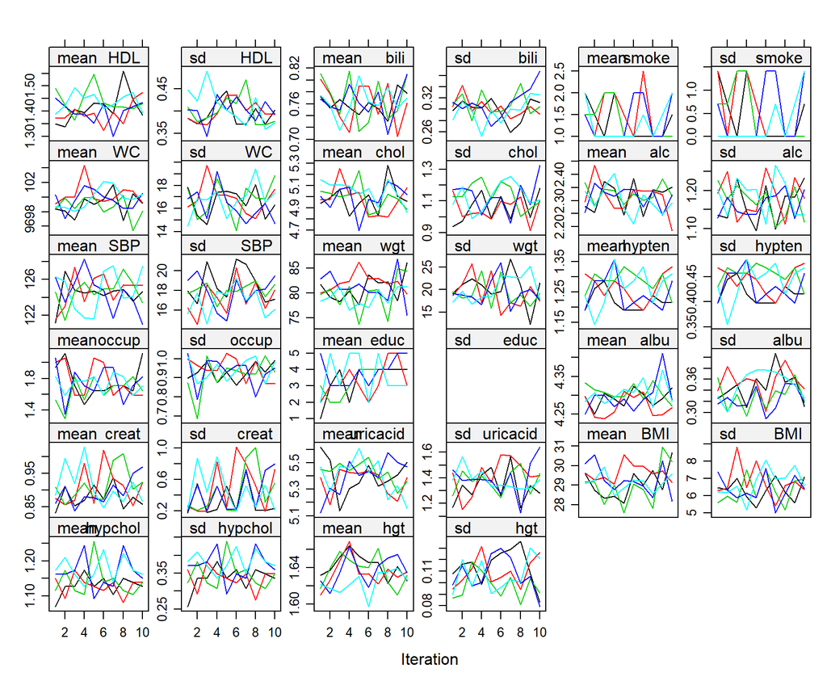

```r
# implemented plotting function (use layout to change the number of rows and columns)
plot(imp, layout = c(6, 6))
```

The chains in `imp` seem to have converged, however it is difficult to judge this based on only 10 iterations. In practice, more iterations should be done.

To save you some time, I ran the imputation again with 30 iterations and the traceplots confirm convergence:

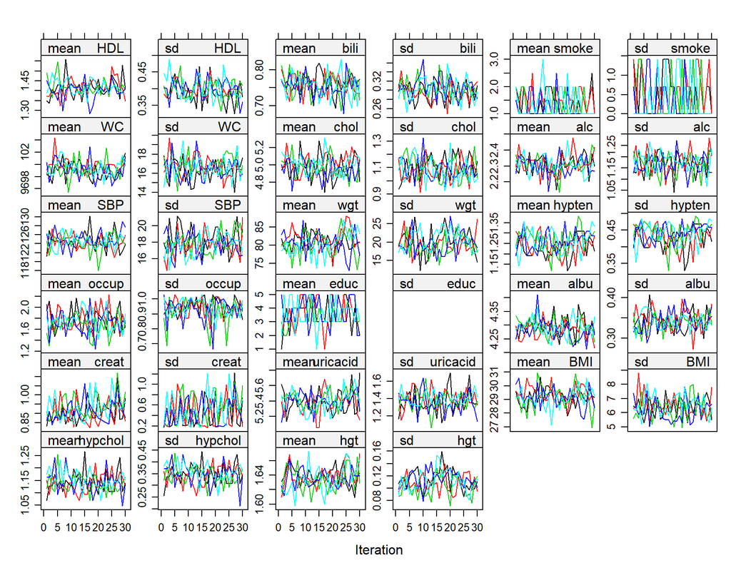

```r
plot(imp30, layout = c(6, 6))
```

#### Continue

In comparison, `impnaive` (in my version with `maxit = 30`) had some convergence problems:

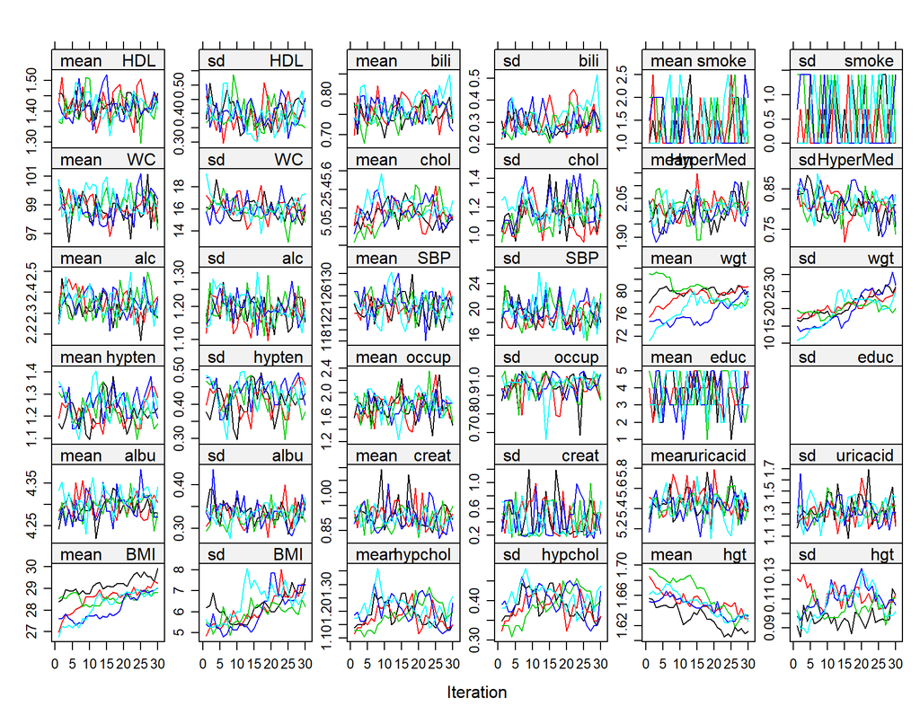

```r
plot(impnaive, layout = c(6, 6))
```

`hgt`, and `wgt` show a clear trend and the chains do not mix well, i.e., there is more variation between the chains than within each chain. (the same is the case for `BMI`).

These are clear signs that there is correlation or identification problems between these variables and some other variables (which is why we made adjustments to the `predictorMatrix` for `imp`).

### Imputed values

Now that we know that `imp` has converged, we can compare the distribution of the imputed values against the distribution of the observed values. When our imputation models fit the data well, they should have similar distributions (conditional on the covariates used in the imputation model).

#### Task 1

- Plot the distributions of the imputed variables (continuous and categorical).
- Make sure the imputed values are realistic (e.g., height of 2.50m or weight of 10kg for adults).

You can use `densityplot()` and `propplot()` to get plots for all continuous and categorical variables.

To check all imputed values you can either get a summary of the `imp` element of the `mids` object or create a complete dataset containing all imputations using the function `complete()` and get the summary of that.

#### Solution 1

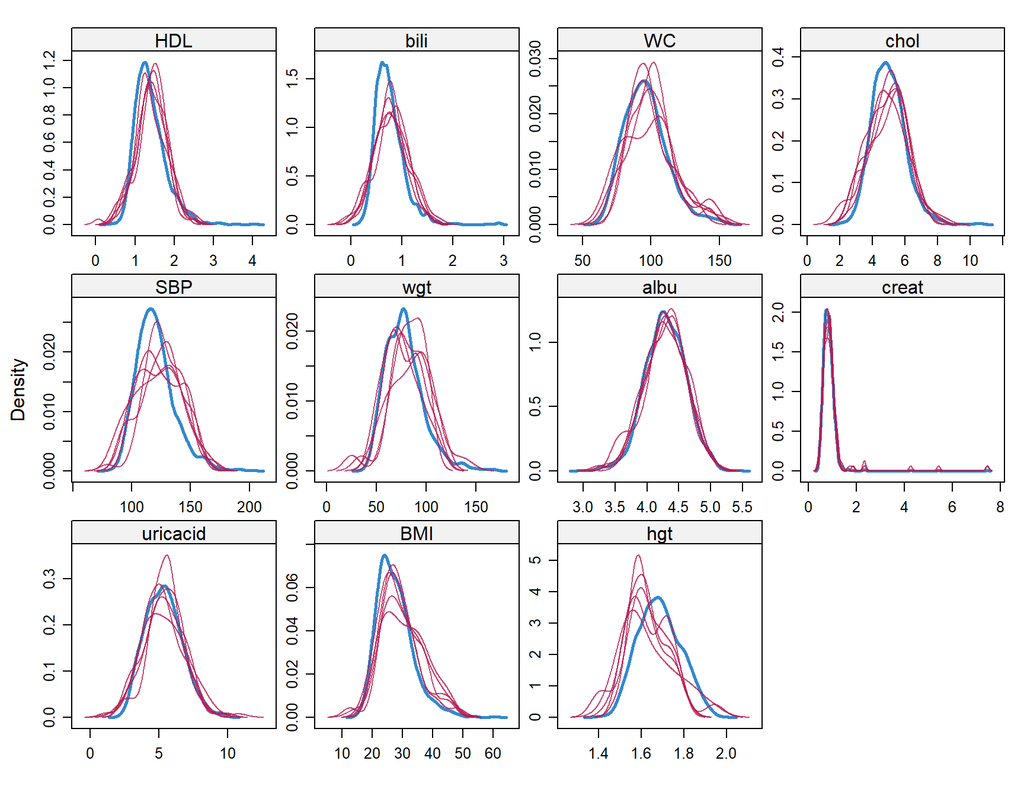

```r
# plot densities of continuous variables
densityplot(imp)
```

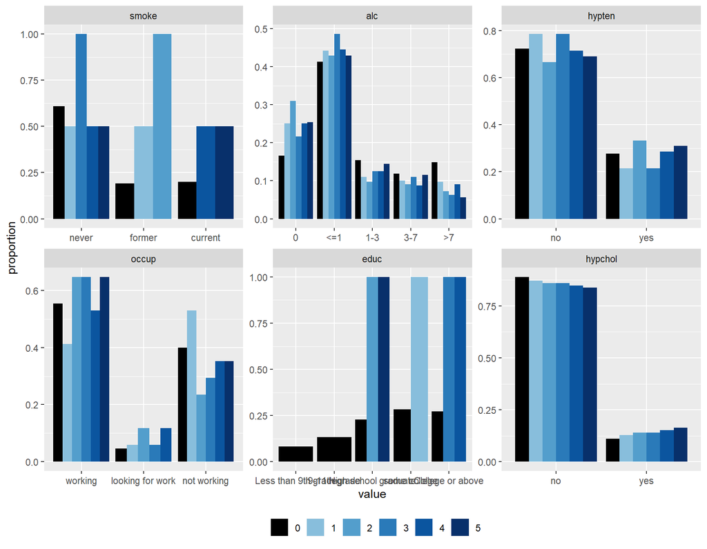

```r
# plot for all categorical variables
propplot(imp)
```

```r
# get the summary of the imputed values
sapply(Filter(function(x) nrow(x) > 0, imp$imp),
       function(x) summary(unlist(x))
)
```

```
## $HDL
##    Min. 1st Qu.  Median    Mean 3rd Qu.    Max.
## 0.06009 1.19649 1.42542 1.42400 1.68001 2.59759
##
## $bili
##    Min. 1st Qu.  Median    Mean 3rd Qu.    Max.
## -0.1174  0.5719  0.7760  0.7856  0.9980  1.7547
##
## $smoke
##   never  former current
##       5       3       2
##
## $WC
##    Min. 1st Qu.  Median    Mean 3rd Qu.    Max.
##   64.46   87.59   98.09   99.49  109.60  152.22
##
## $chol
##    Min. 1st Qu.  Median    Mean 3rd Qu.    Max.
##   1.844   4.163   5.057   4.961   5.763   8.431
##
## $HyperMed
##    Mode    NA's
## logical    4065
##
## $alc
##   0 <=1 1-3 3-7  >7
## 409 712 192 161 121
##
## $SBP
##    Min. 1st Qu.  Median    Mean 3rd Qu.    Max.
##   78.95  111.94  124.57  124.38  137.66  170.34
##
## $wgt
##    Min. 1st Qu.  Median    Mean 3rd Qu.    Max.
##   25.18   68.43   80.13   81.41   94.91  136.87
##
## $hypten
##  no yes
## 153  57
##
```

[output cut: 18 more lines]

```
## $uricacid
##    Min. 1st Qu.  Median    Mean 3rd Qu.    Max.
##   1.094   4.403   5.337   5.375   6.304  10.834
##
## $BMI
##    Min. 1st Qu.  Median    Mean 3rd Qu.    Max.
##   12.53   24.69   28.23   29.55   33.96   48.07
##
## $hypchol
##  no yes
## 368  62
##
## $hgt
##    Min. 1st Qu.  Median    Mean 3rd Qu.    Max.
##   1.400   1.563   1.608   1.631   1.704   1.942
```

```r
# or of the whole dataset
summary(complete(imp, action = 'long'))
```

```
##       .imp        .id              HDL                          race           bili
##  Min.   :1   Min.   :   1.0   Min.   :0.06009   Mexican American  : 560   Min.   :-0.1174
##  1st Qu.:2   1st Qu.: 250.8   1st Qu.:1.11000   Other Hispanic    : 550   1st Qu.: 0.6000
##  Median :3   Median : 500.5   Median :1.32000   Non-Hispanic White:1750   Median : 0.7000
##  Mean   :3   Mean   : 500.5   Mean   :1.39411   Non-Hispanic Black:1145   Mean   : 0.7558
##  3rd Qu.:4   3rd Qu.: 750.2   3rd Qu.:1.60000   other             : 995   3rd Qu.: 0.9000
##  Max.   :5   Max.   :1000.0   Max.   :4.03000                             Max.   : 2.9000
##      smoke        DM          gender           WC              chol            HyperMed
##  never  :3045   no :4265   male  :2465   Min.   : 61.90   Min.   : 1.844   no      : 125
##  former : 958   yes: 735   female:2535   1st Qu.: 85.10   1st Qu.: 4.270   previous: 100
##  current: 997                            Median : 95.40   Median : 4.910   yes     : 710
##                                          Mean   : 96.51   Mean   : 4.995   NA's    :4065
##                                          3rd Qu.:105.52   3rd Qu.: 5.640
##                                          Max.   :154.70   Max.   :10.680
##   alc            SBP              wgt         hypten        cohort                       occup
##  0  : 974   Min.   : 78.95   Min.   : 25.18   no :3618   Length:5000        working         :2769
##  <=1:2117   1st Qu.:109.33   1st Qu.: 63.50   yes:1382   Class :character   looking for work: 236
##  1-3: 717   Median :118.22   Median : 77.11              Mode  :character   not working     :1995
##  3-7: 566   Mean   :120.40   Mean   : 78.42
##  >7 : 626   3rd Qu.:129.33   3rd Qu.: 89.36
##             Max.   :202.00   Max.   :167.83
##       age                          educ           albu           creat           uricacid
##  Min.   :20.00   Less than 9th grade : 415   Min.   :3.000   Min.   :0.4400   Min.   : 1.094
##  1st Qu.:31.00   9-11th grade        : 665   1st Qu.:4.100   1st Qu.:0.6900   1st Qu.: 4.400
##  Median :43.00   High school graduate:1142   Median :4.300   Median :0.8200   Median : 5.300
##  Mean   :45.23   some college        :1416   Mean   :4.289   Mean   :0.8576   Mean   : 5.358
##  3rd Qu.:59.00   College or above    :1362   3rd Qu.:4.500   3rd Qu.:0.9600   3rd Qu.: 6.200
##  Max.   :79.00                               Max.   :5.400   Max.   :7.4600   Max.   :10.834
##       BMI        hypchol         hgt
##  Min.   :12.53   no :4433   Min.   :1.397
##  1st Qu.:23.30   yes: 567   1st Qu.:1.616
##  Median :26.61              Median :1.676
##  Mean   :27.56              Mean   :1.684
##  3rd Qu.:30.85              3rd Qu.:1.753
##  Max.   :60.54              Max.   :1.981
```

Unfortunately, we have some negative imputed values for `bili`. Often, this would not result in bias in the analysis, but may be difficult to explain when providing a summary of the imputed data in a publication. In the present example we can see that the observed values have a slightly right-skewed distribution compared to the imputed values. Re-doing the imputation with `pmm` instead of `norm` for `bili` should fix this. (However, since the imputations seem fine overall, and there is little knowledge gain in re-doing the previous steps, we will skip this repetition in this practical.)

The distributions of the imputed values for `hgt` and `SBP` differ a bit from the distributions of the observed data.

#### Task 2

Investigate if differences in the distributions of observed and imputed values, can be explained by other variables. Check this for

- `SBP` conditional on `gender` and `hypten`
- `hgt` conditional on `gender`
- `alc` conditional on `gender` or `smoke`

#### Solution 2

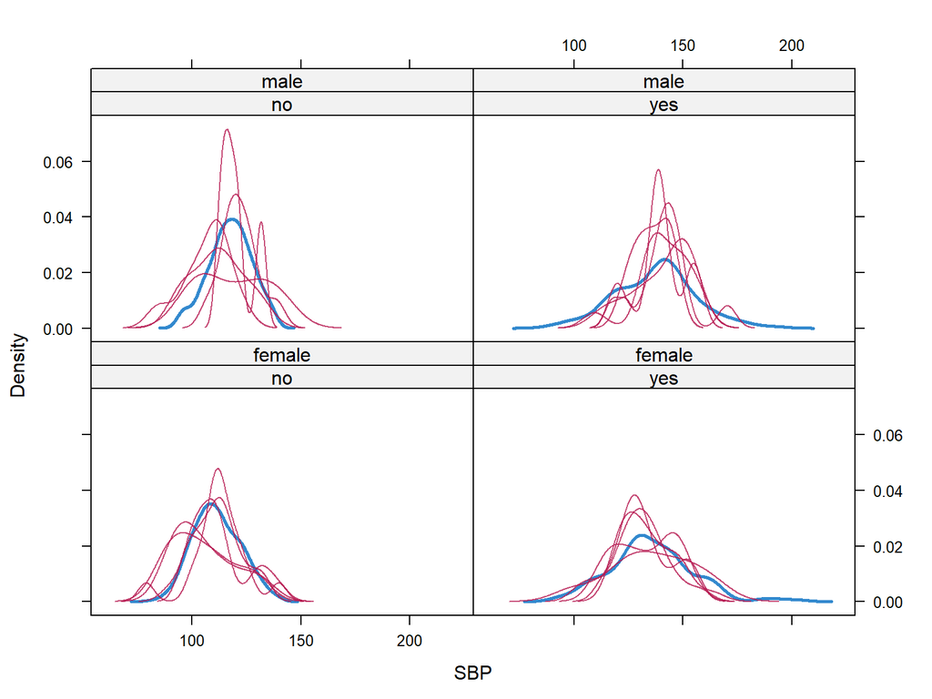

```r
densityplot(imp, ~SBP|hypten + gender)
```

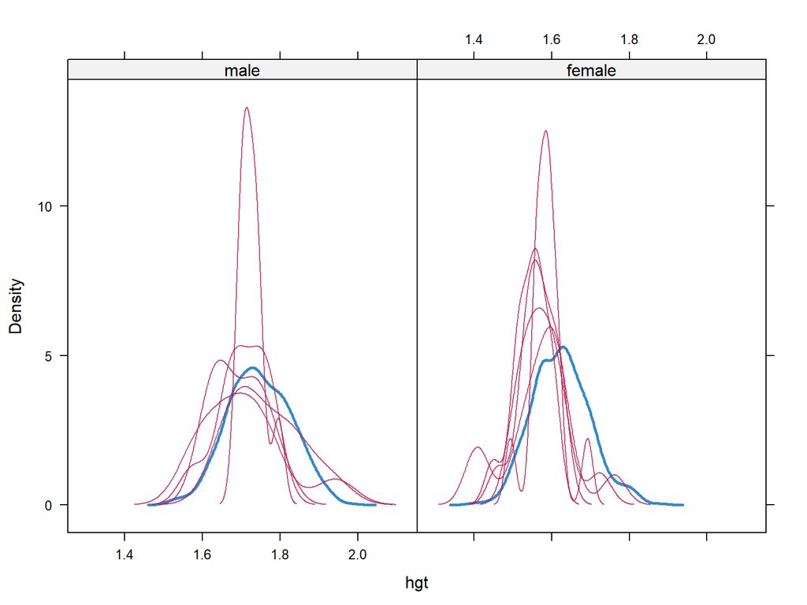

```r
densityplot(imp, ~hgt|gender)
```

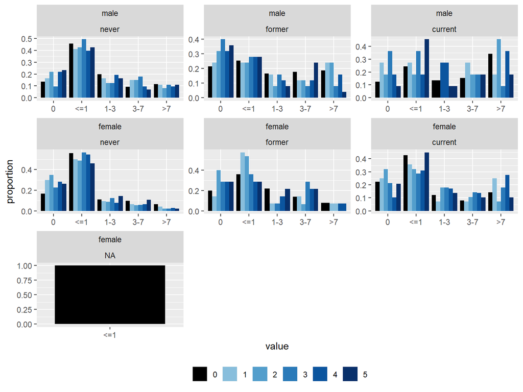

```r
propplot(imp, alc ~ gender + smoke)
```

© Nicole Erler